# Lecture 17

Sean Fahey

2023-04-19

# In Class Work

### Redundancy Analysis (RDA)

- One common use: exploring relationships between species abundance and environment variables.
- Species is typically the response
- Measure abundance of n species in each plot
- Sites/plots are typically the replicates
- Also measure some env. characteristics of each site/plot.
- RDA uses euclidean distances
- Finds linear relationship between predictors and response distances.
- Assumes casual relationship between predictors and response variables
- Response variables can be different types, but must be standardized
- Predictors can be standardized, but don’t have to be

```r
veg = read.csv("bryceveg.txt", header=TRUE, sep=' ', row.names=1)
sites = read.csv("brycesite.txt", header=TRUE, sep=' ', row.names=1)
```

```r
veg.center = scale(veg, center = TRUE, scale = TRUE)

env = with(
  sites,
  cbind(elev, av, slope)
  )
env.scale = as.data.frame(scale(env, center = TRUE, scale = TRUE))
```

```r
veg.rda = rda(
  veg.center ~ elev + av + slope,
  data=env.scale
  )

veg.rda
```

```
## Call: rda(formula = veg.center ~ elev + av + slope, data = env.scale)
##
##                 Inertia Proportion Rank
## Total         169.00000    1.00000
## Constrained     8.69748    0.05146    3
## Unconstrained 160.30252    0.94854  148
## Inertia is variance
##
## Eigenvalues for constrained axes:
##  RDA1  RDA2  RDA3
## 6.337 1.332 1.028
##
## Eigenvalues for unconstrained axes:
##    PC1    PC2    PC3    PC4    PC5    PC6    PC7    PC8
## 12.207  7.367  6.604  5.696  5.324  4.583  4.388  3.629
## (Showing 8 of 148 unconstrained eigenvalues)
```

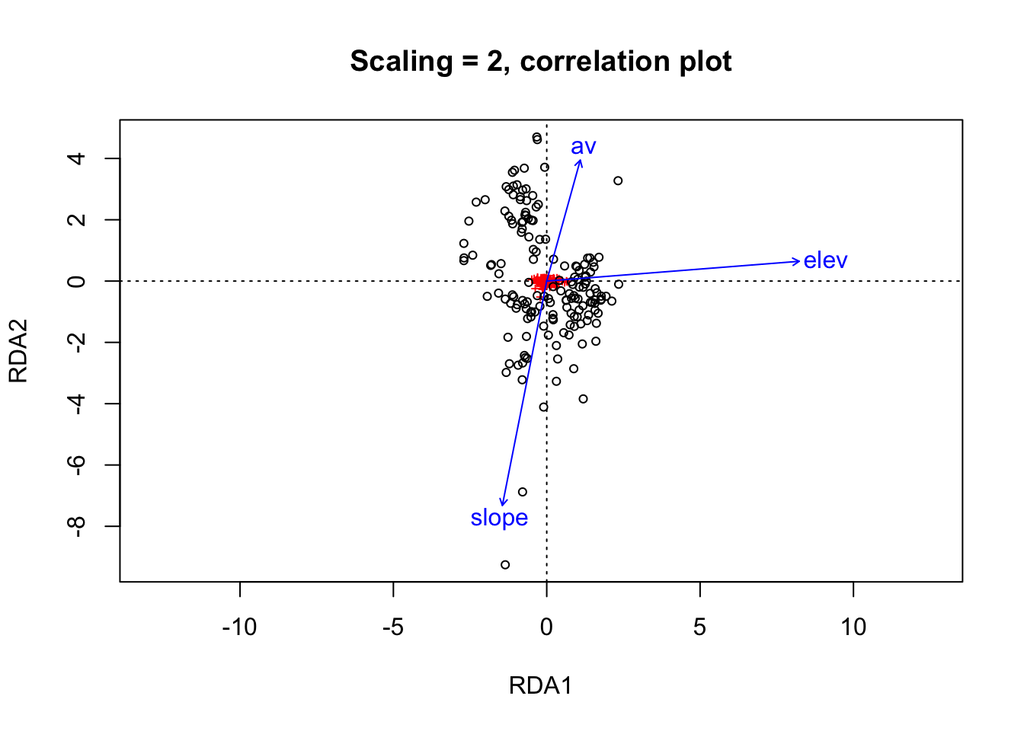

```r
plot(
  veg.rda,
  scaling = 2,
  main = 'Scaling = 2, correlation plot', # title
  display = c('sites', 'species', 'bp')
  )
```

- scaling = 2: emphasize correlation between vectors and distances between sites - similar angles: high correlation - 90 degrees off: no correlation - sites falling further out along predictor are more strongly associated with that predictor

```r
anova(veg.rda)
```

```
## Permutation test for rda under reduced model
## Permutation: free
## Number of permutations: 999
##
## Model: rda(formula = veg.center ~ elev + av + slope, data = env.scale)
##           Df Variance      F Pr(>F)
## Model      3    8.697 2.8213  0.001 ***
## Residual 156  160.303
## ---
## Signif. codes:  0 '***' 0.001 '**' 0.01 '*' 0.05 '.' 0.1 ' ' 1
```

This means that our predictors combined seem to have a significant relationship with the ordination space from the RDA of our species counts

```r
sites$pos = as.factor(sites$pos)
env.scale$pos = sites$pos

veg.rda2 = rda(
  veg.center ~ elev + av + slope + pos,
  data=env.scale
  )

anova(veg.rda2)
```

```
## Permutation test for rda under reduced model
## Permutation: free
## Number of permutations: 999
##
## Model: rda(formula = veg.center ~ elev + av + slope + pos, data = env.scale)
##           Df Variance      F Pr(>F)
## Model      7   15.897 2.2547  0.001 ***
## Residual 152  153.103
## ---
## Signif. codes:  0 '***' 0.001 '**' 0.01 '*' 0.05 '.' 0.1 ' ' 1
```

```r
anova(veg.rda2, by='term')
```

```
## Permutation test for rda under reduced model
## Terms added sequentially (first to last)
## Permutation: free
## Number of permutations: 999
##
## Model: rda(formula = veg.center ~ elev + av + slope + pos, data = env.scale)
##           Df Variance      F Pr(>F)
## elev       1    6.266 6.2212  0.001 ***
## av         1    1.104 1.0963  0.247
## slope      1    1.327 1.3174  0.139
## pos        4    7.200 1.7869  0.001 ***
## Residual 152  153.103
## ---
## Signif. codes:  0 '***' 0.001 '**' 0.01 '*' 0.05 '.' 0.1 ' ' 1
```

Looks like position and elevation are the important terms.

```r
anova(veg.rda2, by='axis')
```

```
## Permutation test for rda under reduced model
## Forward tests for axes
## Permutation: free
## Number of permutations: 999
##
## Model: rda(formula = veg.center ~ elev + av + slope + pos, data = env.scale)
##           Df Variance      F Pr(>F)
## RDA1       1    6.407 6.3612  0.001 ***
## RDA2       1    3.680 3.6534  0.001 ***
## RDA3       1    1.613 1.6015  0.210
## RDA4       1    1.280 1.2706  0.621
## RDA5       1    1.104 1.0963  0.795
## RDA6       1    0.997 0.9897  0.796
## RDA7       1    0.816 0.8100  0.806
## Residual 152  153.103
## ---
## Signif. codes:  0 '***' 0.001 '**' 0.01 '*' 0.05 '.' 0.1 ' ' 1
```

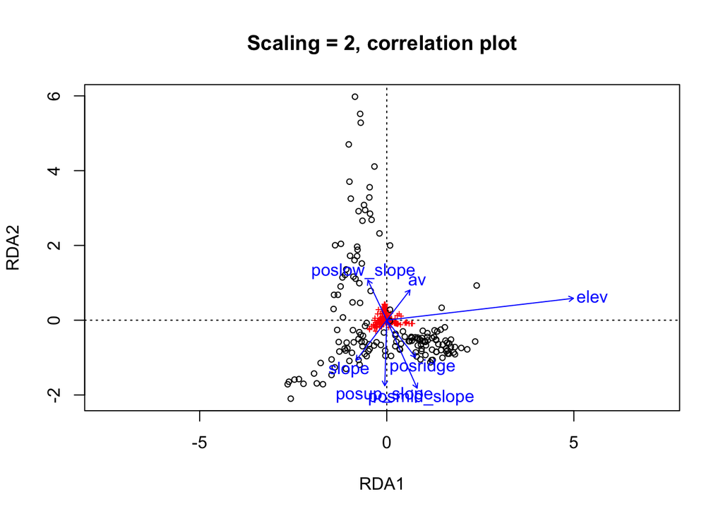

```r
plot(
  veg.rda2,
  scaling = 2,
  main = 'Scaling = 2, correlation plot', # title
  display = c('sites', 'species', 'bp')
  )
```

```r
snails = read.table('SmallSnailData.txt', header=TRUE, sep=' ')
head(snails)
```

```
##      Site Proportionality Circularity SpireHeight Rainfall.mm. DryMonths
## 1  Angola            1.36        0.76        1.69          363         9
## 2 Bahamas            1.51        0.76        1.86         1181         2
## 3  Belize            1.42        0.76        1.85         1500         2
## 4  Brazil            1.43        0.74        1.71         2150         4
## 5 Florida            1.45        0.74        1.86         1004         1
## 6   Haiti            1.49        0.76        1.89         1242         6
##   MeanTempC CanopyHt
## 1      26.4       30
## 2      25.1        3
## 3      29.5        8
## 4      26.4       30
## 5      25.3       10
## 6      27.5       10
```

field sites (col 5-8) can be predictors

```r
shelldata = snails[,2:4]
sitedata = snails[,5:8]

rownames(shelldata) = as.character(snails$Site)
rownames(sitedata) = as.character(snails$Site)

shell.center = as.data.frame(scale(shelldata))
site.center = as.data.frame(scale(sitedata))
```

```r
snail.rda = rda(
  shell.center~Rainfall.mm. + DryMonths + MeanTempC,
  data=site.center,
  scale=FALSE # already scaled, don't do it again.
  )

anova(snail.rda, by = 'term')
```

```
## Permutation test for rda under reduced model
## Terms added sequentially (first to last)
## Permutation: free
## Number of permutations: 999
##
## Model: rda(formula = shell.center ~ Rainfall.mm. + DryMonths + MeanTempC, data = site.center, scale = FALSE)
##              Df Variance      F Pr(>F)
## Rainfall.mm.  1  0.90053 3.3175  0.064 .
## DryMonths     1  0.54009 1.9897  0.154
## MeanTempC     1  0.20217 0.7448  0.596
## Residual      5  1.35722
## ---
## Signif. codes:  0 '***' 0.001 '**' 0.01 '*' 0.05 '.' 0.1 ' ' 1
```

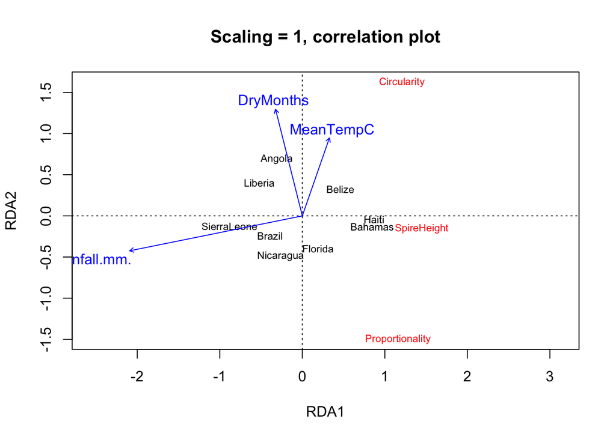

```r
plot(
  snail.rda,
  scaling = 1,
  main = 'Scaling = 1, correlation plot', # title
  display = c('sites', 'species', 'bp')
  )
```

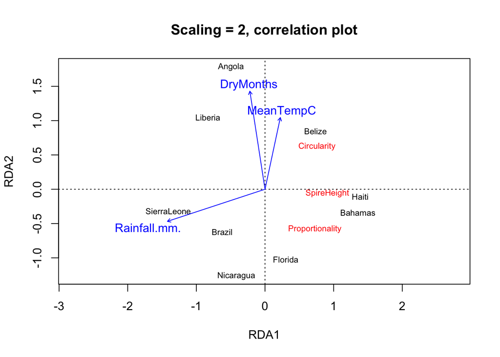

```r
plot(
  snail.rda,
  scaling = 2,
  main = 'Scaling = 2, correlation plot', # title
  display = c('sites', 'species', 'bp')
  )
```

### What if Eudledian distances aren’t ideal?

- CCA: Canonical Correspondence Analysis from vegan
  - Uses chi squared
- Others like Bray-Curtis can also be used.

```r
veg.chi = decostand(veg, method='chi.square')
veg.rda.chi = rda(
  veg.chi ~ elev + av + slope,
  data=env.scale
  )

anova(veg.rda.chi, by='terms')
```

```
## Permutation test for rda under reduced model
## Terms added sequentially (first to last)
## Permutation: free
## Number of permutations: 999
##
## Model: rda(formula = veg.chi ~ elev + av + slope, data = env.scale)
##           Df Variance      F Pr(>F)
## elev       1   0.6887 8.8535  0.001 ***
## av         1   0.0971 1.2488  0.076 .
## slope      1   0.1782 2.2914  0.022 *
## Residual 156  12.1355
## ---
## Signif. codes:  0 '***' 0.001 '**' 0.01 '*' 0.05 '.' 0.1 ' ' 1
```

Using chi squared means rare species will be more emphasized at the expense of common species.

# Notes for FINAL

1. Analyze multivariate data set
1. Do an ordination, and optionally other analyses (like permanova)
2. Components:
1. 10 minute conference style presentation (50 pts)
2. .Rmd file and data file submission (10 pts)

in presentation: reference specific packages, but don’t show slides full of code (but not ggplot, ggfortify, other super basics that don’t manipulate the data). We care more about specifically which rda function from which package we used in write-up: cite packages if you borrow images, credit the author

comment Rmd file HEAVILY. A person should be able to return to this document in a year and understand what the flow was and what each cell is doing without running it.

No extra points for doing NMDS vs. PCA vs. others. But must use the RIGHT ONE.